# How data analysis affects power, reproducibility and biological insight of RNA-seq studies in complex datasets

### *k* = 5

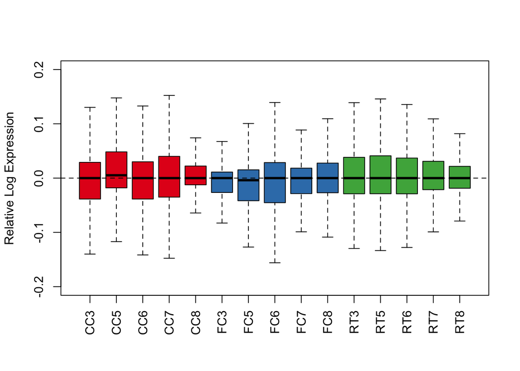

```r
plotRLE(s$normalizedCounts, col = colLib, outline = FALSE, las = 3, ylim = c(-0.2,
    0.2), ylab = "Relative Log Expression", cex.axis = 1, cex.lab = 1)
```

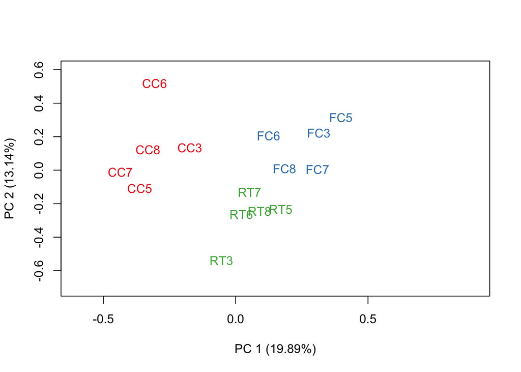

```r
plotPCA(s$normalizedCounts, col = colLib, cex = 1, cex.axis = 1, cex.lab = 1, xlim = c(-0.6,
    0.9), ylim = c(-0.7, 0.6))
```

*k* = 5 is a good choice because the samples show similar RLE distributions and cluster by condition.

### *k* = 10

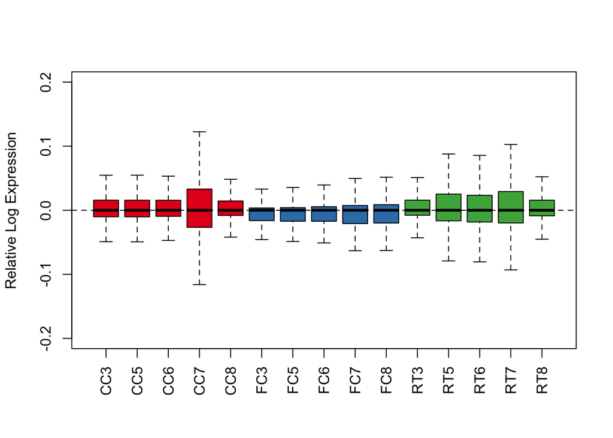

```r
s10 <- RUVs(uq, negCon, k = 10, groups)

plotRLE(s10$normalizedCounts, col = colLib, outline = FALSE, las = 3, ylim = c(-0.2,
    0.2), ylab = "Relative Log Expression", cex.axis = 1, cex.lab = 1)
```

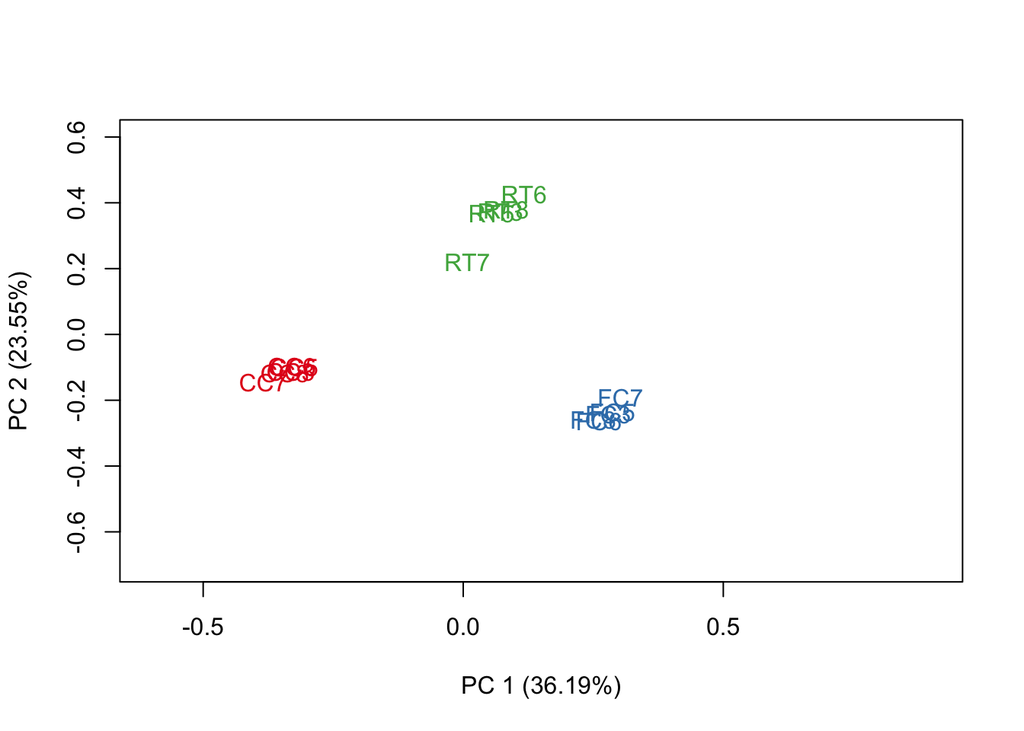

```r
plotPCA(s10$normalizedCounts, col = colLib, cex = 1, cex.axis = 1, cex.lab = 1, xlim = c(-0.6,
    0.9), ylim = c(-0.7, 0.6))
```

When the value of *k* is too high, the RLE distributions become uneven again. More importantly, the model over-corrects for unwanted variation and ends up removing (almost) all the biological variability within the conditions. This is shown in the PCA plot, where all the biological replicate samples are collapsed to almost the same coordinates.

## Set of negative control genes

The choice of the set of negative control genes is somewhat dependent on the dataset. When results on similar datasets are available (either because of previous experiments or through publicly available data), it is often a good choice to use a context-specific set of negative controls.

In the absence of such a tailored set, alternative choices are a set of housekeeping genes, a set of synthetic controls (*spike-ins*), or a set of *in silico* empirical controls (Risso et al. 2014).

A good property of RUVs is its robustness to the choice of negative control genes. To highlight this robustness, we show the performance of RUVs when using all the genes as negative controls (*k* = 5).

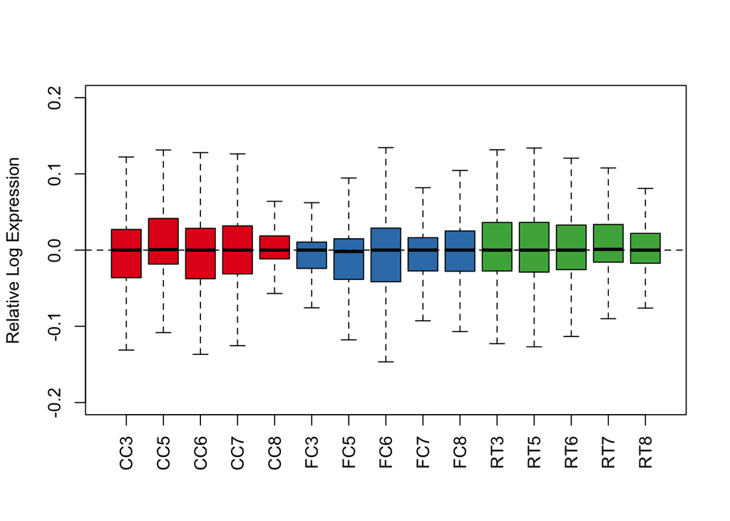

```r
sAll <- RUVs(uq, rownames(uq), k = 5, groups)

plotRLE(sAll$normalizedCounts, col = colLib, outline = FALSE, las = 3, ylim = c(-0.2,
    0.2), ylab = "Relative Log Expression", cex.axis = 1, cex.lab = 1)
```

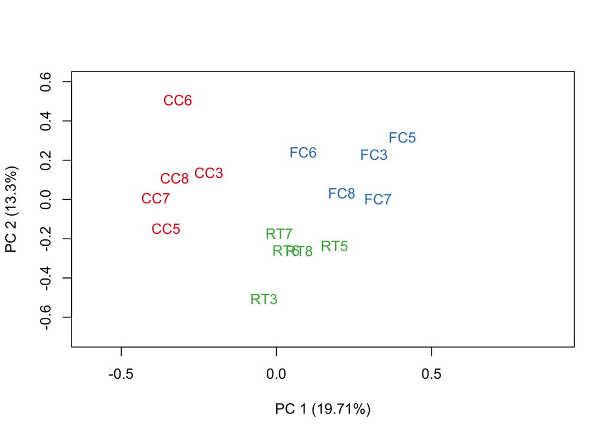

```r
plotPCA(sAll$normalizedCounts, col = colLib, cex = 1, cex.axis = 1, cex.lab = 1,
    xlim = c(-0.6, 0.9), ylim = c(-0.7, 0.6))
```

The results are very close to those based on the set of negative controls (see above).

[session information not shown]

References

Anders, Simon, Paul Theodor Pyl, and Wolfgang Huber. 2015. “HTSeq–A Python Framework to Work with High-Throughput Sequencing Data.” *Bioinformatics* 31 (2). Oxford Univ Press: 166–69.

Flicek, Paul, M Ridwan Amode, Daniel Barrell, Kathryn Beal, Konstantinos Billis, Simon Brent, Denise Carvalho-Silva, et al. 2014. “Ensembl 2014.” *Nucleic Acids Research* 42 (D1). Oxford University Press: D749.

Risso, Davide, John Ngai, Terence P Speed, and Sandrine Dudoit. 2014. “Normalization of RNA-seq Data Using Factor Analysis of Control Genes or Samples.” *Nature Biotechnology* 32 (9). Nature Publishing Group: 896–902.

Wu, Thomas D, and Colin K Watanabe. 2005. “GMAP: A Genomic Mapping and Alignment Program for mRNA and EST Sequences.” *Bioinformatics* 21 (9). Oxford Univ Press: 1859–75.